# Regression: Predicting Home Prices

### 0.0.1 Abstract

The purpose of this project is predict housing prices in Ames, Iowa using regression. Model evaluation is conducted using root-mean-square-error.

Load Packages

```r
library(statsr)
library(dplyr)
library(BAS)
```

```r
library(ggplot2)
library(MASS)
library(scales)
```

Load Data

```r
load("ames_train.gz")
ames_train$age = 2018 - ames_train$Year.Built
ames_train$total.bath = ames_train$Full.Bath + (.5 * ames_train$Half.Bath)

#cleaning data to only include only normal sale conditions
ames_train = ames_train %>%
  filter(Sale.Condition == "Normal")
```

### 0.0.2 Exploratory Data Analysis (EDA)

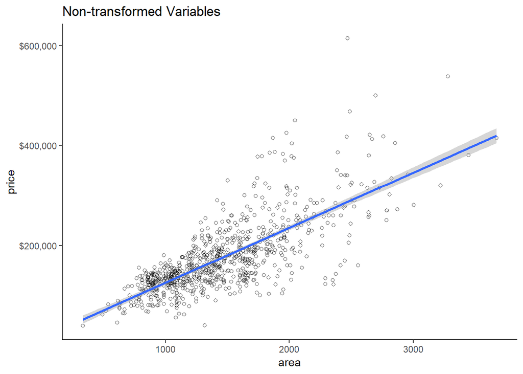

```r
ggplot(ames_train, aes(x = area, y= price)) +
  geom_jitter(shape = 1, alpha = .7) +
  stat_smooth(method = lm, se = TRUE) +
  theme_classic() +
  labs(title = "Non-transformed Variables") +
  scale_y_continuous(labels = dollar)
```

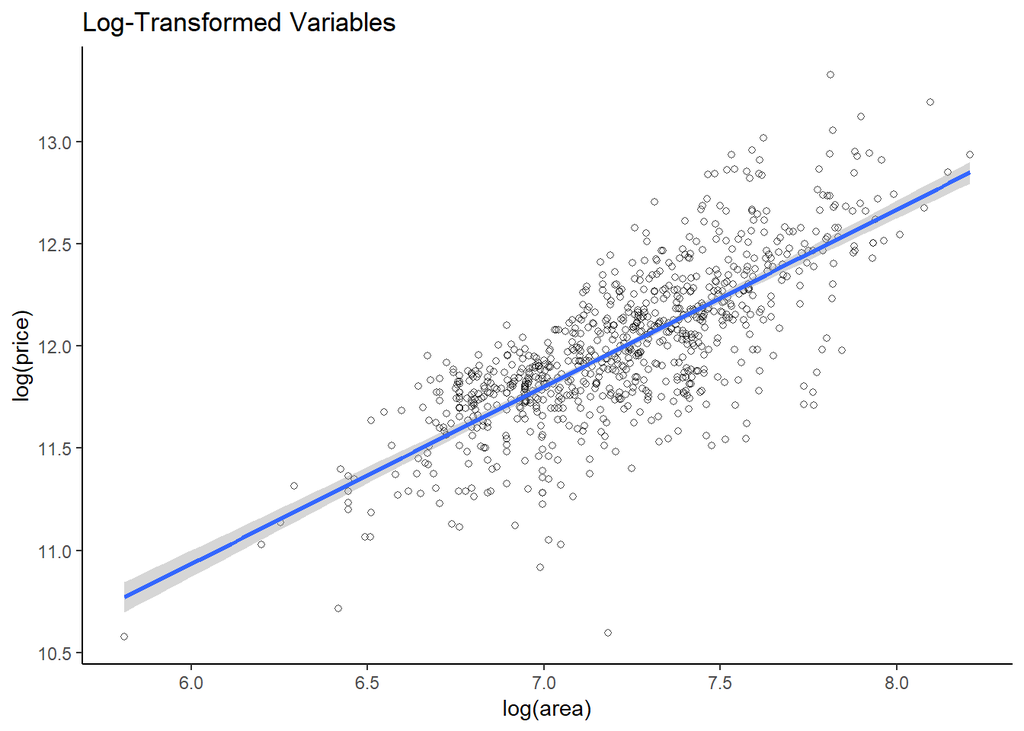

```r
ggplot(ames_train, aes(x = log(area), y= log(price))) +
  geom_jitter(shape = 1, alpha = .7) +
  stat_smooth(method = lm, se = TRUE) +
  theme_classic() +
  labs(title = "Log-Transformed Variables")
```

After plotting each continous explanatory variable against price, I decided that log-transformation improved linearity and/or homoskedasticity in all cases. In the example plots below of price vs area, you can see that linearity and homoskedasticity were greatly improved by transforming the variables.

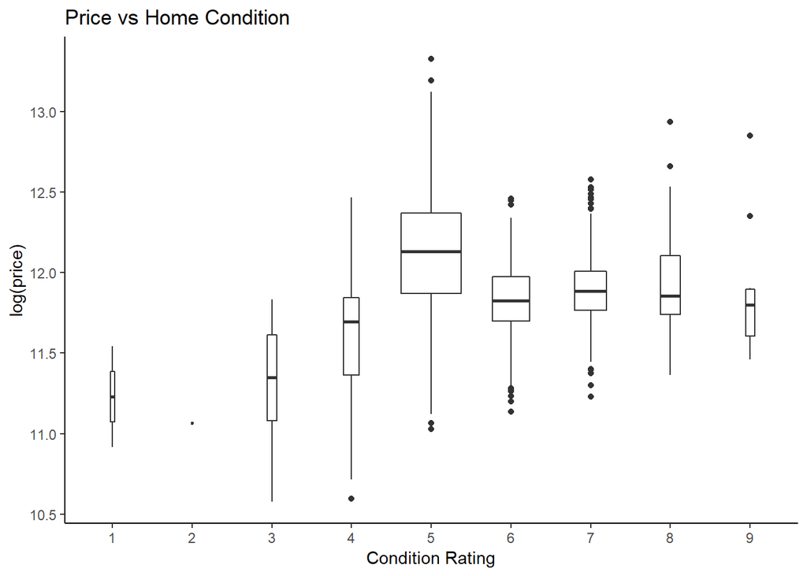

```r
#price and overall condition

ggplot(ames_train, aes(x=as.factor(Overall.Cond), y = log(price))) +
  geom_boxplot(varwidth = TRUE) +
  theme_classic()+
  labs(title = "Price vs Home Condition", x = "Condition Rating")
```

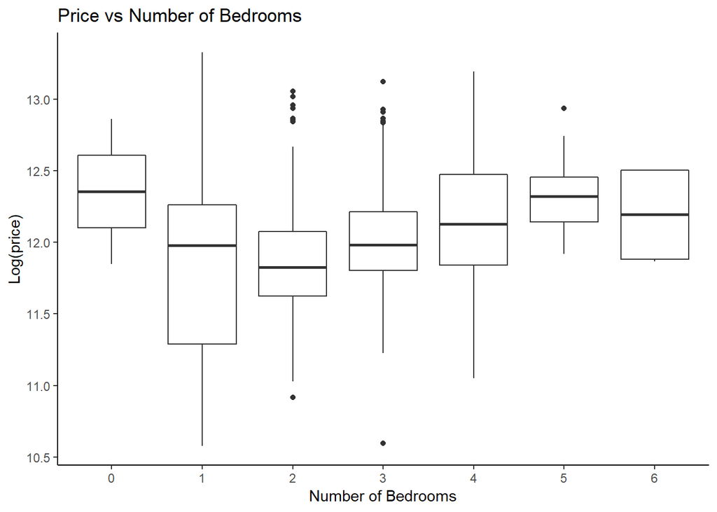

```r
#bedrooms and price
ggplot(ames_train, aes(x = as.factor(Bedroom.AbvGr), y=log(price))) +
  geom_boxplot() +
  theme_classic()+
  labs(title = "Price vs Number of Bedrooms", y = "Log(price)", x = "Number of Bedrooms")
```

## 0.1 Model Building

I used linear regression to predict the home’s price as explained by square footage, lot square footage, neighborhood, overall quality, overall condition, central air conditioning, age, number of bathrooms, number of bedrooms, garage size, land slope, basement square feet, paved driveway, and wood deck.

Most of the variables are significant at the 5% level–meaning that, for each variable, the chances of seeing an effect of this size due to random chance is less than 5%. Total Bath and Paved Driveway do not appear to be significant.

Surpisingly the number of bedroom coefficient is negative. This means that, according to our model, higher numbers of bathrooms and bedrooms translate to a lower sales price. This is most likely due to multicollinearity with the area variable. I would interpret this situation as: homebuyers prefer fewer rooms for a given size house.

```r
#build linear model
ames_train$age = 2018 - ames_train$Year.Built
ames_train$total.bath = ames_train$Full.Bath + (.5 * ames_train$Half.Bath)
model.full = lm(log(price) ~ log(area) + log(Lot.Area) + Neighborhood + Overall.Qual +
                Overall.Cond + Central.Air + log(age) + total.bath + Bedroom.AbvGr + Garage.Cars + Land.Slope +
                log(Total.Bsmt.SF+1) + Paved.Drive + log(Pool.Area + 1) + (Wood.Deck.SF+1),
                data = ames_train)
#model summary
summary(model.full)
```

```
##
## Call:
## lm(formula = log(price) ~ log(area) + log(Lot.Area) + Neighborhood +
##     Overall.Qual + Overall.Cond + Central.Air + log(age) + total.bath +
##     Bedroom.AbvGr + Garage.Cars + Land.Slope + log(Total.Bsmt.SF +
##     1) + Paved.Drive + log(Pool.Area + 1) + (Wood.Deck.SF + 1),
##     data = ames_train)
##
## Residuals:
##      Min       1Q   Median       3Q      Max
## -0.77251 -0.05988  0.00198  0.06435  0.39113
##
## Coefficients:
##                          Estimate Std. Error t value Pr(>|t|)
## (Intercept)             7.295e+00  1.639e-01  44.518  < 2e-16 ***
## log(area)               4.503e-01  2.478e-02  18.172  < 2e-16 ***
## log(Lot.Area)           1.195e-01  1.180e-02  10.130  < 2e-16 ***
## NeighborhoodBlueste    -3.864e-02  7.651e-02  -0.505 0.613659
## NeighborhoodBrDale     -1.103e-01  6.051e-02  -1.823 0.068624 .
## NeighborhoodBrkSide    -1.448e-02  5.094e-02  -0.284 0.776238
## NeighborhoodClearCr    -9.297e-03  5.853e-02  -0.159 0.873830
## NeighborhoodCollgCr    -4.281e-02  4.513e-02  -0.949 0.343074
## NeighborhoodCrawfor     1.083e-01  5.228e-02   2.072 0.038579 *
## NeighborhoodEdwards    -6.393e-02  4.805e-02  -1.330 0.183745
## NeighborhoodGilbert    -7.120e-02  4.719e-02  -1.509 0.131755
## NeighborhoodGreens      1.781e-01  7.008e-02   2.541 0.011231 *
## NeighborhoodGrnHill     5.061e-01  8.949e-02   5.656 2.17e-08 ***
## NeighborhoodIDOTRR     -1.148e-01  5.276e-02  -2.175 0.029913 *
## NeighborhoodMeadowV    -8.850e-02  5.285e-02  -1.675 0.094399 .
## NeighborhoodMitchel    -1.208e-02  4.754e-02  -0.254 0.799563
## NeighborhoodNAmes       9.393e-03  4.741e-02   0.198 0.842984
## NeighborhoodNoRidge     9.283e-02  4.803e-02   1.933 0.053604 .
## NeighborhoodNPkVill     2.739e-02  7.001e-02   0.391 0.695676
## NeighborhoodNridgHt     8.958e-02  4.617e-02   1.940 0.052692 .
## NeighborhoodNWAmes     -1.758e-02  4.878e-02  -0.360 0.718732
## NeighborhoodOldTown    -9.426e-02  5.033e-02  -1.873 0.061488 .
## NeighborhoodSawyer     -3.137e-03  4.859e-02  -0.065 0.948533
## NeighborhoodSawyerW    -8.260e-02  4.690e-02  -1.761 0.078554 .
## NeighborhoodSomerst     3.231e-02  4.473e-02   0.722 0.470318
## NeighborhoodStoneBr     9.389e-02  5.284e-02   1.777 0.076011 .
```

[output cut: 8 more lines]

```
## Bedroom.AbvGr          -2.336e-02  7.008e-03  -3.334 0.000896 ***
## Garage.Cars             3.953e-02  7.531e-03   5.249 1.97e-07 ***
## Land.SlopeMod           6.456e-02  2.114e-02   3.053 0.002338 **
## Land.SlopeSev           1.297e-01  7.154e-02   1.813 0.070141 .
## log(Total.Bsmt.SF + 1)  2.898e-02  3.785e-03   7.656 5.60e-14 ***
## Paved.DriveP           -3.809e-02  2.615e-02  -1.457 0.145564
## Paved.DriveY            1.113e-02  1.927e-02   0.577 0.563799
## log(Pool.Area + 1)      1.864e-02  1.085e-02   1.718 0.086176 .
## Wood.Deck.SF            1.693e-04  3.489e-05   4.851 1.48e-06 ***
## ---
## Signif. codes:  0 '***' 0.001 '**' 0.01 '*' 0.05 '.' 0.1 ' ' 1
##
## Residual standard error: 0.1081 on 791 degrees of freedom
## Multiple R-squared:  0.9239, Adjusted R-squared:  0.9199
## F-statistic: 228.8 on 42 and 791 DF,  p-value: < 2.2e-16
```

### 0.1.1 Model Selection

Two methods of selection were used to improve the initial model (model.full). The first method is called stepAIC, which is a method of selection that weighs goodness-of-fit (least sum of squared residuals) against complexity (the number of variables), to guard against overfitting. The stepAIC model wound up being very similar to the original model in that it dropped the total bath variable.

```r
#model selection using stepAIC
model.AIC = stepAIC(model.full, k=2)
```

```
## Start:  AIC=-3669.18
## log(price) ~ log(area) + log(Lot.Area) + Neighborhood + Overall.Qual +
##     Overall.Cond + Central.Air + log(age) + total.bath + Bedroom.AbvGr +
##     Garage.Cars + Land.Slope + log(Total.Bsmt.SF + 1) + Paved.Drive +
##     log(Pool.Area + 1) + (Wood.Deck.SF + 1)
##
##                          Df Sum of Sq     RSS     AIC
## - total.bath              1    0.0152  9.2559 -3669.8
## <none>                                 9.2407 -3669.2
## - Paved.Drive             2    0.0552  9.2959 -3668.2
## - log(Pool.Area + 1)      1    0.0345  9.2752 -3668.1
## - Land.Slope              2    0.1362  9.3769 -3661.0
## - Bedroom.AbvGr           1    0.1299  9.3705 -3659.5
## - Central.Air             1    0.2372  9.4778 -3650.0
## - Wood.Deck.SF            1    0.2749  9.5156 -3646.7
## - Garage.Cars             1    0.3218  9.5625 -3642.6
## - log(Total.Bsmt.SF + 1)  1    0.6847  9.9254 -3611.6
## - log(Lot.Area)           1    1.1989 10.4395 -3569.4
## - log(age)                1    1.3028 10.5435 -3561.2
## - Overall.Cond            1    1.6462 10.8869 -3534.5
## - Overall.Qual            1    1.7124 10.9531 -3529.4
## - Neighborhood           26    2.5621 11.8027 -3517.1
## - log(area)               1    3.8579 13.0986 -3380.2
##
## Step:  AIC=-3669.81
## log(price) ~ log(area) + log(Lot.Area) + Neighborhood + Overall.Qual +
##     Overall.Cond + Central.Air + log(age) + Bedroom.AbvGr + Garage.Cars +
##     Land.Slope + log(Total.Bsmt.SF + 1) + Paved.Drive + log(Pool.Area +
##     1) + Wood.Deck.SF
##
##                          Df Sum of Sq     RSS     AIC
## <none>                                 9.2559 -3669.8
## - Paved.Drive             2    0.0551  9.3110 -3668.9
## - log(Pool.Area + 1)      1    0.0345  9.2904 -3668.7
## - Land.Slope              2    0.1344  9.3903 -3661.8
## - Bedroom.AbvGr           1    0.1564  9.4123 -3657.8
## - Central.Air             1    0.2420  9.4979 -3650.3
## - Wood.Deck.SF            1    0.2698  9.5257 -3647.9
## - Garage.Cars             1    0.3179  9.5738 -3643.7
## - log(Total.Bsmt.SF + 1)  1    0.7147  9.9706 -3609.8
## - log(Lot.Area)           1    1.2567 10.5126 -3565.6
## - log(age)                1    1.3209 10.5768 -3560.6
## - Overall.Cond            1    1.6426 10.8985 -3535.6
## - Overall.Qual            1    1.7433 10.9992 -3527.9
## - Neighborhood           26    2.6334 11.8893 -3513.0
## - log(area)               1    4.7042 13.9601 -3329.1
```

```r
summary(model.AIC)
```

```
##
## Call:
## lm(formula = log(price) ~ log(area) + log(Lot.Area) + Neighborhood +
##     Overall.Qual + Overall.Cond + Central.Air + log(age) + Bedroom.AbvGr +
##     Garage.Cars + Land.Slope + log(Total.Bsmt.SF + 1) + Paved.Drive +
##     log(Pool.Area + 1) + Wood.Deck.SF, data = ames_train)
##
## Residuals:
##      Min       1Q   Median       3Q      Max
## -0.76492 -0.05942  0.00088  0.06265  0.37833
##
## Coefficients:
##                          Estimate Std. Error t value Pr(>|t|)
## (Intercept)             7.335e+00  1.601e-01  45.813  < 2e-16 ***
## log(area)               4.368e-01  2.177e-02  20.063  < 2e-16 ***
## log(Lot.Area)           1.213e-01  1.170e-02  10.370  < 2e-16 ***
## NeighborhoodBlueste    -3.342e-02  7.639e-02  -0.437 0.661871
## NeighborhoodBrDale     -1.111e-01  6.052e-02  -1.836 0.066726 .
## NeighborhoodBrkSide    -1.410e-02  5.095e-02  -0.277 0.782109
## NeighborhoodClearCr    -1.199e-02  5.849e-02  -0.205 0.837694
## NeighborhoodCollgCr    -4.397e-02  4.512e-02  -0.974 0.330143
## NeighborhoodCrawfor     1.056e-01  5.223e-02   2.023 0.043447 *
## NeighborhoodEdwards    -6.360e-02  4.806e-02  -1.323 0.186077
## NeighborhoodGilbert    -7.617e-02  4.700e-02  -1.621 0.105457
## NeighborhoodGreens      1.813e-01  7.004e-02   2.588 0.009823 **
## NeighborhoodGrnHill     5.048e-01  8.950e-02   5.641 2.36e-08 ***
## NeighborhoodIDOTRR     -1.146e-01  5.277e-02  -2.172 0.030121 *
## NeighborhoodMeadowV    -8.846e-02  5.286e-02  -1.673 0.094633 .
## NeighborhoodMitchel    -1.195e-02  4.755e-02  -0.251 0.801629
## NeighborhoodNAmes       1.073e-02  4.740e-02   0.226 0.821018
## NeighborhoodNoRidge     9.099e-02  4.801e-02   1.895 0.058417 .
## NeighborhoodNPkVill     1.849e-02  6.958e-02   0.266 0.790493
## NeighborhoodNridgHt     8.987e-02  4.617e-02   1.946 0.051955 .
## NeighborhoodNWAmes     -2.166e-02  4.866e-02  -0.445 0.656371
## NeighborhoodOldTown    -9.455e-02  5.034e-02  -1.878 0.060728 .
## NeighborhoodSawyer     -1.608e-03  4.858e-02  -0.033 0.973606
## NeighborhoodSawyerW    -8.690e-02  4.675e-02  -1.859 0.063432 .
## NeighborhoodSomerst     2.944e-02  4.467e-02   0.659 0.510078
## NeighborhoodStoneBr     9.162e-02  5.282e-02   1.735 0.083182 .
## NeighborhoodSWISU      -3.438e-02  5.901e-02  -0.583 0.560359
## NeighborhoodTimber      3.310e-02  5.078e-02   0.652 0.514655
## NeighborhoodVeenker     4.075e-02  5.853e-02   0.696 0.486493
## Overall.Qual            6.505e-02  5.326e-03  12.213  < 2e-16 ***
## Overall.Cond            4.991e-02  4.210e-03  11.855  < 2e-16 ***
## Central.AirY            9.144e-02  2.009e-02   4.551 6.18e-06 ***
## log(age)               -1.545e-01  1.453e-02 -10.631  < 2e-16 ***
## Bedroom.AbvGr          -2.506e-02  6.850e-03  -3.658 0.000271 ***
## Garage.Cars             3.926e-02  7.529e-03   5.215 2.35e-07 ***
## Land.SlopeMod           6.432e-02  2.115e-02   3.042 0.002430 **
## Land.SlopeSev           1.275e-01  7.153e-02   1.783 0.075021 .
## log(Total.Bsmt.SF + 1)  2.944e-02  3.764e-03   7.820 1.68e-14 ***
## Paved.DriveP           -3.557e-02  2.606e-02  -1.365 0.172671
## Paved.DriveY            1.344e-02  1.917e-02   0.701 0.483545
## log(Pool.Area + 1)      1.865e-02  1.085e-02   1.719 0.086063 .
## Wood.Deck.SF            1.675e-04  3.487e-05   4.804 1.86e-06 ***
## ---
## Signif. codes:  0 '***' 0.001 '**' 0.01 '*' 0.05 '.' 0.1 ' ' 1
##
## Residual standard error: 0.1081 on 792 degrees of freedom
## Multiple R-squared:  0.9238, Adjusted R-squared:  0.9199
## F-statistic: 234.2 on 41 and 792 DF,  p-value: < 2.2e-16
```

```r
#summary(ames_train)
#model selection using BAS.lm
model.bas = bas.lm(log(price) ~ log(area) + log(Lot.Area) + Overall.Qual+ Overall.Cond+ Central.Air+ log(age)+ total.bath+
                      Bedroom.AbvGr + Garage.Cars +Land.Slope + log(Total.Bsmt.SF+1) + Paved.Drive +
                     log(Pool.Area + 1) + (Wood.Deck.SF+1) + Neighborhood,
                data = ames_train,
                prior = "AIC",
                modelprior = uniform())
#BAS model summary
round(summary(model.bas),3)
```

```
##                        P(B != 0 | Y)  model 1  model 2  model 3  model 4
## Intercept                      1.000    1.000    1.000    1.000    1.000
## log(area)                      1.000    1.000    1.000    1.000    1.000
## log(Lot.Area)                  1.000    1.000    1.000    1.000    1.000
## Overall.Qual                   1.000    1.000    1.000    1.000    1.000
## Overall.Cond                   1.000    1.000    1.000    1.000    1.000
## Central.AirY                   1.000    1.000    1.000    1.000    1.000
## log(age)                       1.000    1.000    1.000    1.000    1.000
## total.bath                     0.423    0.000    1.000    0.000    0.000
## Bedroom.AbvGr                  0.995    1.000    1.000    1.000    1.000
## Garage.Cars                    1.000    1.000    1.000    1.000    1.000
## Land.SlopeMod                  0.987    1.000    1.000    1.000    1.000
## Land.SlopeSev                  0.987    1.000    1.000    1.000    1.000
## log(Total.Bsmt.SF + 1)         1.000    1.000    1.000    1.000    1.000
## Paved.DriveP                   0.616    1.000    1.000    0.000    1.000
## Paved.DriveY                   0.616    1.000    1.000    0.000    1.000
## log(Pool.Area + 1)             0.634    1.000    1.000    1.000    0.000
## Wood.Deck.SF                   1.000    1.000    1.000    1.000    1.000
## NeighborhoodBlueste            1.000    1.000    1.000    1.000    1.000
## NeighborhoodBrDale             1.000    1.000    1.000    1.000    1.000
## NeighborhoodBrkSide            1.000    1.000    1.000    1.000    1.000
## NeighborhoodClearCr            1.000    1.000    1.000    1.000    1.000
## NeighborhoodCollgCr            1.000    1.000    1.000    1.000    1.000
## NeighborhoodCrawfor            1.000    1.000    1.000    1.000    1.000
## NeighborhoodEdwards            1.000    1.000    1.000    1.000    1.000
## NeighborhoodGilbert            1.000    1.000    1.000    1.000    1.000
## NeighborhoodGreens             1.000    1.000    1.000    1.000    1.000
## NeighborhoodGrnHill            1.000    1.000    1.000    1.000    1.000
## NeighborhoodIDOTRR             1.000    1.000    1.000    1.000    1.000
## NeighborhoodMeadowV            1.000    1.000    1.000    1.000    1.000
## NeighborhoodMitchel            1.000    1.000    1.000    1.000    1.000
## NeighborhoodNAmes              1.000    1.000    1.000    1.000    1.000
## NeighborhoodNoRidge            1.000    1.000    1.000    1.000    1.000
## NeighborhoodNPkVill            1.000    1.000    1.000    1.000    1.000
## NeighborhoodNridgHt            1.000    1.000    1.000    1.000    1.000
## NeighborhoodNWAmes             1.000    1.000    1.000    1.000    1.000
## NeighborhoodOldTown            1.000    1.000    1.000    1.000    1.000
## NeighborhoodSawyer             1.000    1.000    1.000    1.000    1.000
## NeighborhoodSawyerW            1.000    1.000    1.000    1.000    1.000
## NeighborhoodSomerst            1.000    1.000    1.000    1.000    1.000
```

[output cut: 43 more lines]

```
## NeighborhoodNridgHt       1.000
## NeighborhoodNWAmes        1.000
## NeighborhoodOldTown       1.000
## NeighborhoodSawyer        1.000
## NeighborhoodSawyerW       1.000
## NeighborhoodSomerst       1.000
## NeighborhoodStoneBr       1.000
## NeighborhoodSWISU         1.000
## NeighborhoodTimber        1.000
## NeighborhoodVeenker       1.000
## BF                        0.451
## PostProbs                 0.100
## R2                        0.924
## dim                      41.000
## logmarg                -970.731
```

```r
#model coefficients
coef.bas = coef(model.bas, estimator = "BMA")
coef.bas$postmean = round(coef.bas$postmean, 3)
coef.bas$postsd = round(coef.bas$postsd, 3)
coef.bas$postprobs = round(coef.bas$postprobs, 3)
coef.bas
```

```
##
##  Marginal Posterior Summaries of Coefficients:
##
##  Using  BMA
##
##  Based on the top  34299 models
##                         post mean  post SD  post p(B != 0)
## Intercept               11.9960     0.0040   1.0000
## log(area)                0.4430     0.0240   1.0000
## log(Lot.Area)            0.1200     0.0120   1.0000
## Overall.Qual             0.0650     0.0050   1.0000
## Overall.Cond             0.0500     0.0040   1.0000
## Central.AirY             0.0920     0.0200   1.0000
## log(age)                -0.1580     0.0150   1.0000
## total.bath              -0.0060     0.0100   0.4226
## Bedroom.AbvGr           -0.0240     0.0070   0.9947
## Garage.Cars              0.0390     0.0080   1.0000
## Land.SlopeMod            0.0660     0.0220   0.9874
## Land.SlopeSev            0.1290     0.0730   0.9874
## log(Total.Bsmt.SF + 1)   0.0290     0.0040   1.0000
## Paved.DriveP            -0.0230     0.0270   0.6164
## Paved.DriveY             0.0080     0.0160   0.6164
## log(Pool.Area + 1)       0.0120     0.0120   0.6339
## Wood.Deck.SF             0.0000     0.0000   1.0000
## NeighborhoodBlueste     -0.0340     0.0770   1.0000
## NeighborhoodBrDale      -0.1090     0.0610   1.0000
## NeighborhoodBrkSide     -0.0150     0.0510   1.0000
## NeighborhoodClearCr     -0.0100     0.0590   1.0000
## NeighborhoodCollgCr     -0.0430     0.0450   1.0000
## NeighborhoodCrawfor      0.1070     0.0520   1.0000
## NeighborhoodEdwards     -0.0640     0.0480   1.0000
## NeighborhoodGilbert     -0.0740     0.0470   1.0000
## NeighborhoodGreens       0.1820     0.0700   1.0000
## NeighborhoodGrnHill      0.5070     0.0900   1.0000
## NeighborhoodIDOTRR      -0.1170     0.0530   1.0000
## NeighborhoodMeadowV     -0.0870     0.0530   1.0000
## NeighborhoodMitchel     -0.0110     0.0480   1.0000
## NeighborhoodNAmes        0.0120     0.0480   1.0000
## NeighborhoodNoRidge      0.0920     0.0480   1.0000
## NeighborhoodNPkVill      0.0240     0.0700   1.0000
## NeighborhoodNridgHt      0.0900     0.0460   1.0000
## NeighborhoodNWAmes      -0.0170     0.0490   1.0000
## NeighborhoodOldTown     -0.0950     0.0500   1.0000
## NeighborhoodSawyer       0.0000     0.0490   1.0000
## NeighborhoodSawyerW     -0.0850     0.0470   1.0000
## NeighborhoodSomerst      0.0310     0.0450   1.0000
## NeighborhoodStoneBr      0.0930     0.0530   1.0000
## NeighborhoodSWISU       -0.0350     0.0590   1.0000
## NeighborhoodTimber       0.0340     0.0510   1.0000
## NeighborhoodVeenker      0.0470     0.0590   1.0000
```

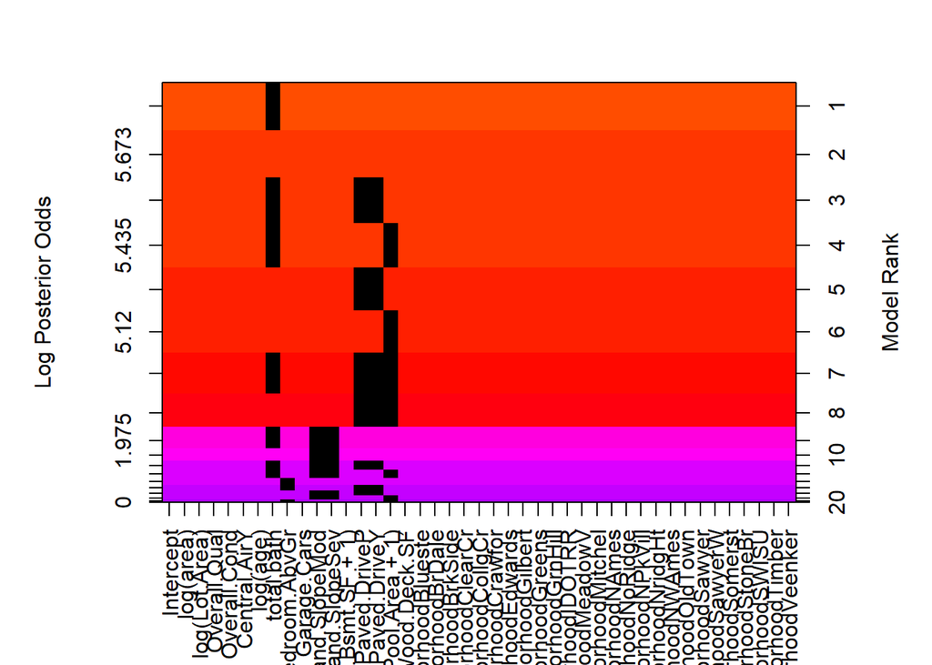

```r
#visualization of BAS model
image(model.bas)
```

### 0.1.2 Initial Model Residuals

Plotting the residuals vs fitted values we see random scatter centered around zero–meaning our model is linear with constant variability. The histogram of the residuals shows that they are nearly normal with a mean of zero.

Observation 611 in the data set is an outlier and, as such, has the largest residual. I looked at the individual observation and see that the home is old, small, lacks upgrades, and is in fair-poor condition, but I can see no reason why it should be removed from the data set. Outliers such as these have large squared errors and affect the model’s overall goodness-of-fit, but without a good reason to omit, the outlier it must remain.

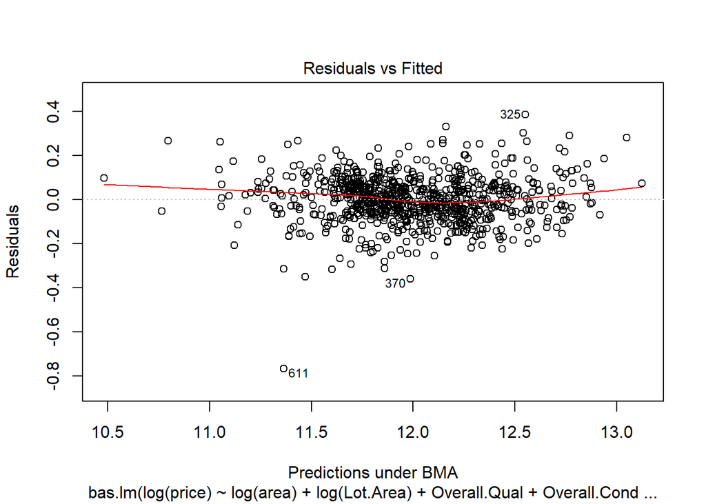

```r
#residual plot BAS model
plot(model.bas, which = 1)
```

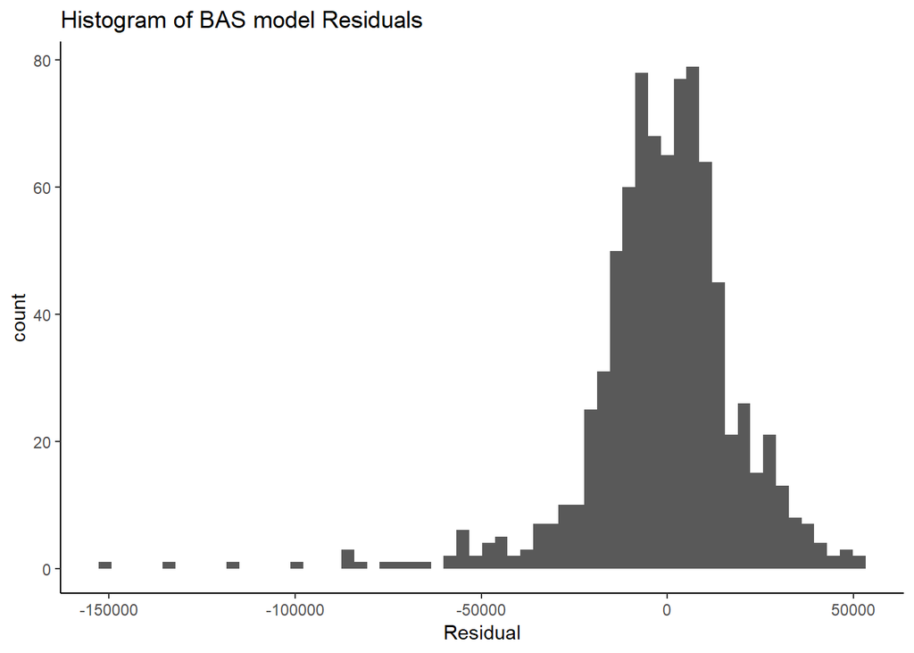

```r
#histogram of residuals
pred.BAS.train = predict(model.bas, newdata = ames_train, estimator = "BMA")
res = as.data.frame(exp(pred.BAS.train$fit) - ames_train$price)
colnames(res) = c("Residual")

ggplot(res, aes(x = Residual))+
  geom_histogram(bins=60)+
  theme_classic()+
  labs(title = "Histogram of BAS model Residuals")
```

```r
#explore unusual residual from model
ames_train[611,]
```

```
## # A tibble: 1 x 83
##      PID  area price MS.SubClass MS.Zoning Lot.Frontage Lot.Area Street
##    <int> <int> <int>       <int> <fct>            <int>    <int> <fct>
## 1 9.11e8  1317 40000          70 C (all)             50     8500 Pave
## # ... with 75 more variables: Alley <fct>, Lot.Shape <fct>,
## #   Land.Contour <fct>, Utilities <fct>, Lot.Config <fct>,
## #   Land.Slope <fct>, Neighborhood <fct>, Condition.1 <fct>,
## #   Condition.2 <fct>, Bldg.Type <fct>, House.Style <fct>,
## #   Overall.Qual <int>, Overall.Cond <int>, Year.Built <int>,
## #   Year.Remod.Add <int>, Roof.Style <fct>, Roof.Matl <fct>,
## #   Exterior.1st <fct>, Exterior.2nd <fct>, Mas.Vnr.Type <fct>,
## #   Mas.Vnr.Area <int>, Exter.Qual <fct>, Exter.Cond <fct>,
## #   Foundation <fct>, Bsmt.Qual <fct>, Bsmt.Cond <fct>,
## #   Bsmt.Exposure <fct>, BsmtFin.Type.1 <fct>, BsmtFin.SF.1 <int>,
## #   BsmtFin.Type.2 <fct>, BsmtFin.SF.2 <int>, Bsmt.Unf.SF <int>,
## #   Total.Bsmt.SF <int>, Heating <fct>, Heating.QC <fct>,
## #   Central.Air <fct>, Electrical <fct>, X1st.Flr.SF <int>,
## #   X2nd.Flr.SF <int>, Low.Qual.Fin.SF <int>, Bsmt.Full.Bath <int>,
## #   Bsmt.Half.Bath <int>, Full.Bath <int>, Half.Bath <int>,
## #   Bedroom.AbvGr <int>, Kitchen.AbvGr <int>, Kitchen.Qual <fct>,
## #   TotRms.AbvGrd <int>, Functional <fct>, Fireplaces <int>,
## #   Fireplace.Qu <fct>, Garage.Type <fct>, Garage.Yr.Blt <int>,
## #   Garage.Finish <fct>, Garage.Cars <int>, Garage.Area <int>,
## #   Garage.Qual <fct>, Garage.Cond <fct>, Paved.Drive <fct>,
## #   Wood.Deck.SF <int>, Open.Porch.SF <int>, Enclosed.Porch <int>,
## #   X3Ssn.Porch <int>, Screen.Porch <int>, Pool.Area <int>, Pool.QC <fct>,
## #   Fence <fct>, Misc.Feature <fct>, Misc.Val <int>, Mo.Sold <int>,
## #   Yr.Sold <int>, Sale.Type <fct>, Sale.Condition <fct>, age <dbl>,
## #   total.bath <dbl>
```

### 0.1.3 Model RMSE

```r
#calculate training set RMSE
#full model RMSE
pred.full.train = predict(model.full, newdata = ames_train)
RMSE.full.train = sqrt(mean((exp(pred.full.train) - ames_train$price)^2))

#AIC model RMSE
pred.AIC.train = predict(model.AIC, newdata=ames_train)
RMSE.AIC.train = sqrt(mean((exp(pred.AIC.train) - ames_train$price)^2))

#BAS model RMSE
pred.BAS.train = (predict(model.bas, newdata = ames_train, estimator = "BMA"))
RMSE.BAS.train = sqrt(mean(exp(pred.BAS.train$fit) - ames_train$price)^2)

#create a data frame
RMSE.df = data.frame(c("Full Model", "Stepwise AIC Model", "BAS model"),
                     dollar(c(RMSE.full.train, RMSE.AIC.train, RMSE.BAS.train)))
colnames(RMSE.df) = c("Model", "RMSE Training Data")
RMSE.df
```

```
##                Model RMSE Training Data
## 1         Full Model         $20,493.40
## 2 Stepwise AIC Model         $20,565.47
## 3          BAS model          $1,223.98
```

### 0.1.4 Overfitting

Use out of sample data to check the model against overfitting.

```r
load("ames_test.gz")
ames_test = subset(ames_test, Sale.Condition == "Normal")
ames_test$total.bath = ames_test$Full.Bath + (ames_test$Half.Bath * 0.5)
ames_test$age = 2018 - ames_test$Year.Built

# the 'Landmrk' neighborhood was not in our training set (meaning we have no data on any houses from this neighborhood in
# reflected in our model) so we unable to  make prediction about it in our testing set.
# Because it is a single observation, I am removing it from the testing set
# another option would be to change "Landmrk" to the next most similar neighborhood and then make a prediction
ames_test = subset(ames_test, Neighborhood != 'Landmrk')
```

The RMSE for the BAS model on the testing set is $2564, double what it was on the training set. I am not changing the model because some overfitting is to be expected, and $2564 is still acceptable in my opinion.

```r
#calculate testing set RMSE
#full model RMSE
pred.full.test = predict(model.full, newdata = ames_test)
RMSE.full.test = sqrt(mean((exp(pred.full.test) - ames_test$price)^2))

#AIC model RMSE
pred.AIC.test = predict(model.AIC, newdata=ames_test)
RMSE.AIC.test = sqrt(mean((exp(pred.AIC.test) - ames_test$price)^2))

#BAS model RMSE
pred.BAS.test = (predict(model.bas, newdata = ames_test, estimator = "BMA"))
RMSE.BAS.test = sqrt(mean(exp(pred.BAS.test$fit) - ames_test$price)^2)

#create a data frame
RMSE.df = data.frame(c("Full Model", "Stepwise AIC Model", "BAS model"),
                     dollar(c(RMSE.full.train, RMSE.AIC.train, RMSE.BAS.train)),
                     dollar(c(RMSE.full.test, RMSE.AIC.test, RMSE.BAS.test)))
colnames(RMSE.df) = c("Model", "RMSE Train Data", "RMSE Test Data")
RMSE.df
```

```
##                Model RMSE Train Data RMSE Test Data
## 1         Full Model      $20,493.40     $24,171.06
## 2 Stepwise AIC Model      $20,565.47     $24,085.59
## 3          BAS model       $1,223.98      $2,564.26
```

### 0.1.5 Model Evaluation

What are some strengths and weaknesses of the model?

A largest strength of the model is accuracy. The median home price in the out of testing data set is $162,500 and the average error in our predicted prices is only $2564.

One weakness of the model is scalability. The neighborhood catagorical variable makes the model only applicable to Ames, Iowa and only in the listed neighborhoods. I think a further refinement to the model, that could improve scalability, is a two process algorithm. In lieu of the “neighborhood” variable, I would recommend adding all of the “macro” variables relating to the home’s location (urban vs rural, median surrounding home price, crime rates, school ratings, etc) and then catagorizing each home by its “macro” variables via k-means clustering. Then, for each cluster, fit a Bayesian regression model based on the home’s “micro” variables (area, lot area, condition, etc) to predict price. This clustering step would be, in effect, creating a proxy for the neighborhood variable.

Another weakness of the model is interpretability. Linear regression is complicated and can be hard to understand to begin with, and Bayesian regression is even more so. All of the continous variables are log-transformed which detracts from interpretability. For instance, using non-transformed variables, a 1 square foot increase in home area would increase the price of the home (in dollars) by the coeffecient. However, using log-transformed variables, we would have to interpret that as: a 1% increase in home’s area increases the percentage of the home value by the coeffecient, a slightly less useful form. Also, the fitted values have to be exponentiated to be put back in their usable form, dollars.

### 0.1.6 Section 4.4 Final Model Validation

```r
load("ames_validation.gz")
ames_validation$total.bath = ames_validation$Full.Bath + (ames_validation$Half.Bath * 0.5)
ames_validation$age = 2018 - ames_validation$Year.Built
```

The final model’s RMSE for the validation set is $1648, between the RMSE for the training and testing sets. Again the model’s accuracy and lack of overfitting is demonstrated.

```r
#RMSE validation data
pred.val = predict(model.bas, newdata=ames_validation, estimator = "BMA")
RMSE.val = sqrt(mean(exp(pred.val$fit) - ames_validation$price )^2)
RMSE.val.df = data.frame(c("Training Set", "Testing Set", "Validation Set"),
                         dollar(c(RMSE.BAS.train, RMSE.BAS.test, RMSE.val)))
colnames(RMSE.val.df) = c("Data Set", "RMSE")
RMSE.val.df
```

```
##         Data Set      RMSE
## 1   Training Set $1,223.98
## 2    Testing Set $2,564.26
## 3 Validation Set $1,648.95
```

```r
#Confidence Interval validation data
pred.val.ci = predict(model.bas, newdata=ames_validation, estimator = "BMA",
                      prediction = TRUE, se.fit = TRUE)
```

```r
#confidence interval
CI.bas = (exp(confint(pred.val.ci)))
CI.df = data.frame(CI.bas[,1], CI.bas[,2], ames_validation$price)
colnames(CI.df) = c("lower", "upper", "price")

prop_in_CI = CI.df %>%
  summarize(prop_in = mean(price > lower & price < upper),
            num_in = sum(price > lower & price < upper),
            num_out = n() - num_in,
            n = n())

prop_in_CI
```

```
##     prop_in num_in num_out   n
## 1 0.9501966    725      38 763
```

## 0.2 Conclusion

In doing this model I learned that it is important to plot each explanatory variable against the dependent variable on a simple scatterplot before building any models. This helps to reveal relationships, particularly linearity and homoskedasticity, and if the variables should be transformed. Another great lesson is the importance of fitting many models and comparing results by RMSE. All the models tested had very high R^2 but drastically different RMSE. If I had stopped at the AIC model based on R^2 and p-value significance, I would have been stuck with an RMSE of over $20,000, which would have been a fairly useless model.